# FFT With Gaps

CM Berry

2024-07-25

## Set Up

We are interested in the question of whether we can use the FFT to calculate the Fourier Transform of uniformly spaced data which contain gaps.

In this case, our data are uniformly spaced other than the fact that we have stretches of time where the processes are unobserved (i.e. gaps) as shown below.

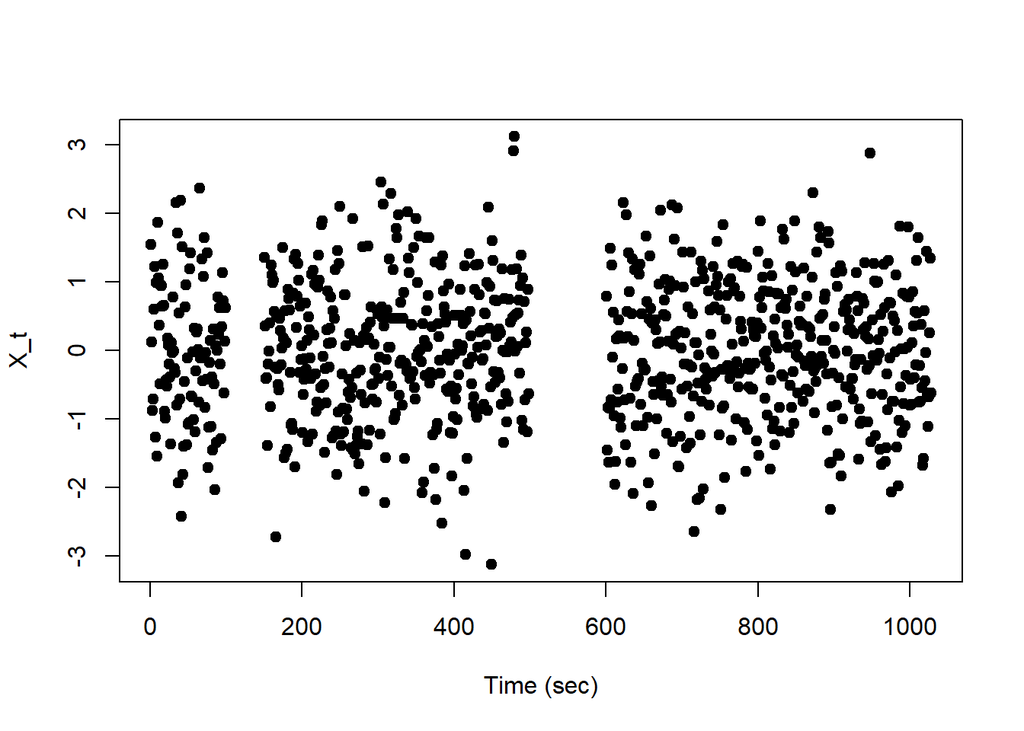

Say we would like to calculate the Fourier Transform of this discrete signal. We can do this with the DFT (Discrete Fourier Transform)

Imagine we could observe the entire signal above.

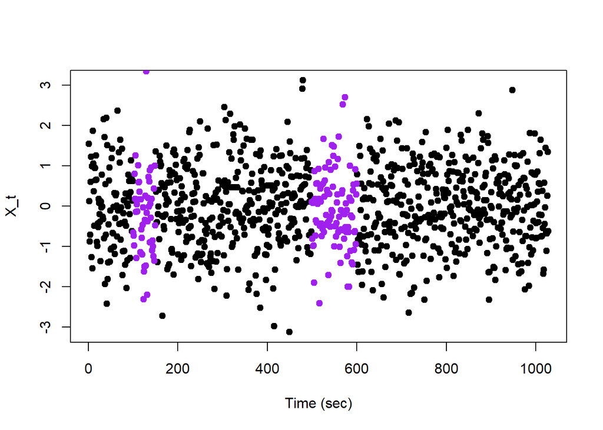

The DFT of a signal $\{x_t\}_{t = 0}^{N-1}$, as shown above, is given by:

$$D[f_j] = \sum_{t = 0}^{N-1} x_t
\exp(-i2\pi f_j t)$$

for $f_j = \frac{j - 1}{N}, j = 1, \ldots, N$.

Consider the case where this signal might be missing (the purple points above). Then those points would simply not contribute to this sum at the given frequency.

Then the original series $x_t$ where $x_t = NA$ for some $t$ should yield the same DFT as the one where $x_t = 0$ for those time points where the data is missing.

## Plots

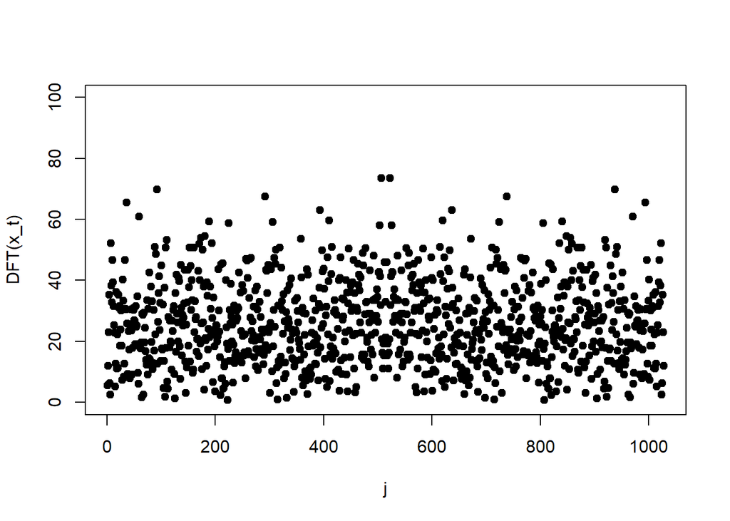

```r
# plotting DFT of x_t with 0 values where NA
y_zeros <- y_miss
y_zeros[is.na(y_miss)] <- 0
plot(abs(fft0(y_zeros)), ylab = "DFT(x_t)", xlab = "j", pch = 19, ylim = c(0,100))
```

Now compare to the DFT calculated with the FFT of the same signal:

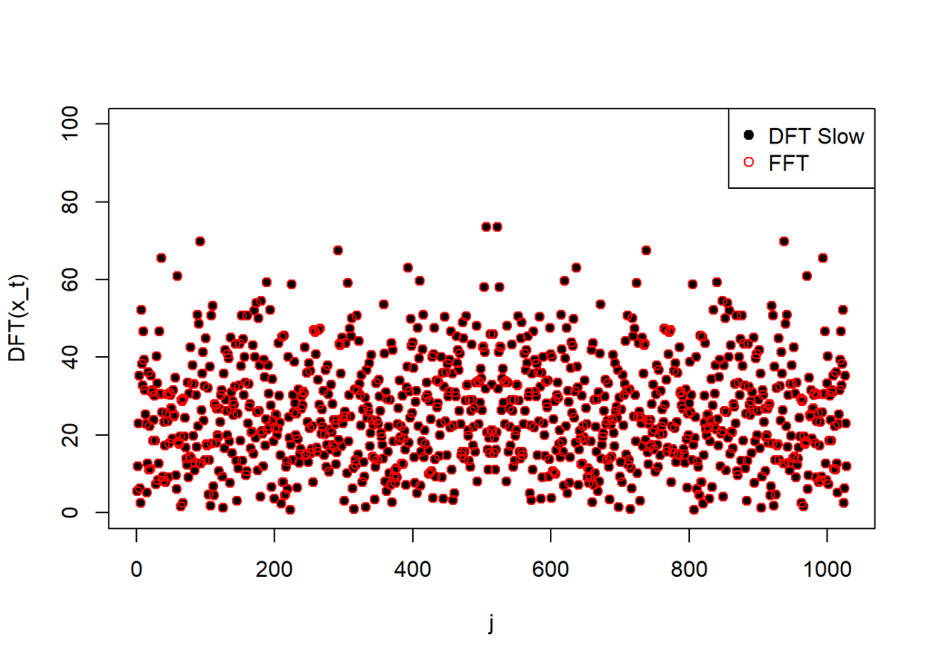

```r
# plotting comparing slow calculation of DFT with FFT output:
plot(abs(fft0(y_zeros)), ylab = "DFT(x_t)", xlab = "j", pch = 19, ylim = c(0,100))
points(abs(fft(y_zeros)), col = "red")
legend("topright",legend = c("DFT Slow", "FFT"), col = c("black", "red"), pch = c(19, 1))
```

We can see from this plot they match, so that’s great!

Next we want to show that the DFT with the missing values set to NA will yeild the same results.

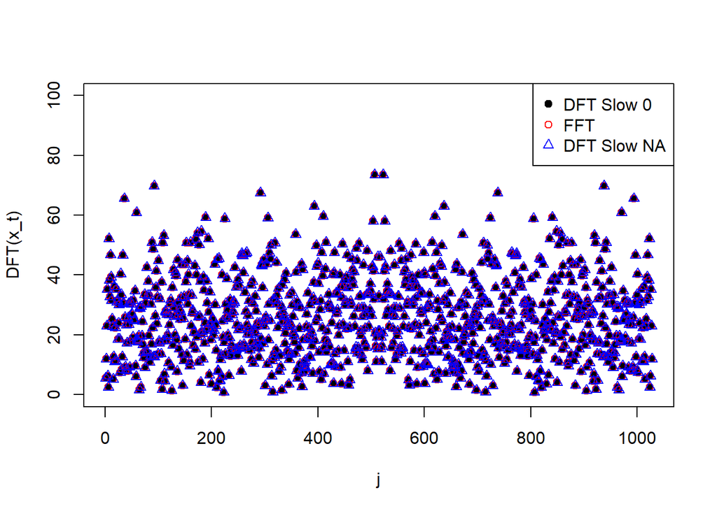

```r
# comparing DFT of zeroed signal and NA signal
plot(abs(fft0(y_zeros)), ylab = "DFT(x_t)", xlab = "j", pch = 19, ylim = c(0,100))
points(abs(fft(y_zeros)), col = "red")
points(abs(fft0(y_miss)), col = "blue", pch = 2)
legend("topright",legend = c("DFT Slow 0", "FFT", "DFT Slow NA"), col = c("black", "red", "blue"), pch = c(19, 1, 2))
```

Again we see a match.

Therefore we have the following equivalence:

For $f_j$, $j = 1,\ldots, N$:

$$DFT_0(f_j) = FFT_0(f_j) =
DFT_{NA}(f_j)$$

In particular, this is good evidence that taking the FFT of $x_t$ where NA values are set to 0 will give the same results as it would if we were to do the DFT the “slow” way (equation) with $x_t$ where missing values are set to NA.

## Full Data vs. Missing Data

In theory, we should get a similar transform for a data with gaps as without because these came from the same underlying process. Does this hold? (This is a separate question from above and doesn’t affect whether we should use the FFT on gapped data, merely a question to explore about our use of this spectral estimate).

Let’s take a look:

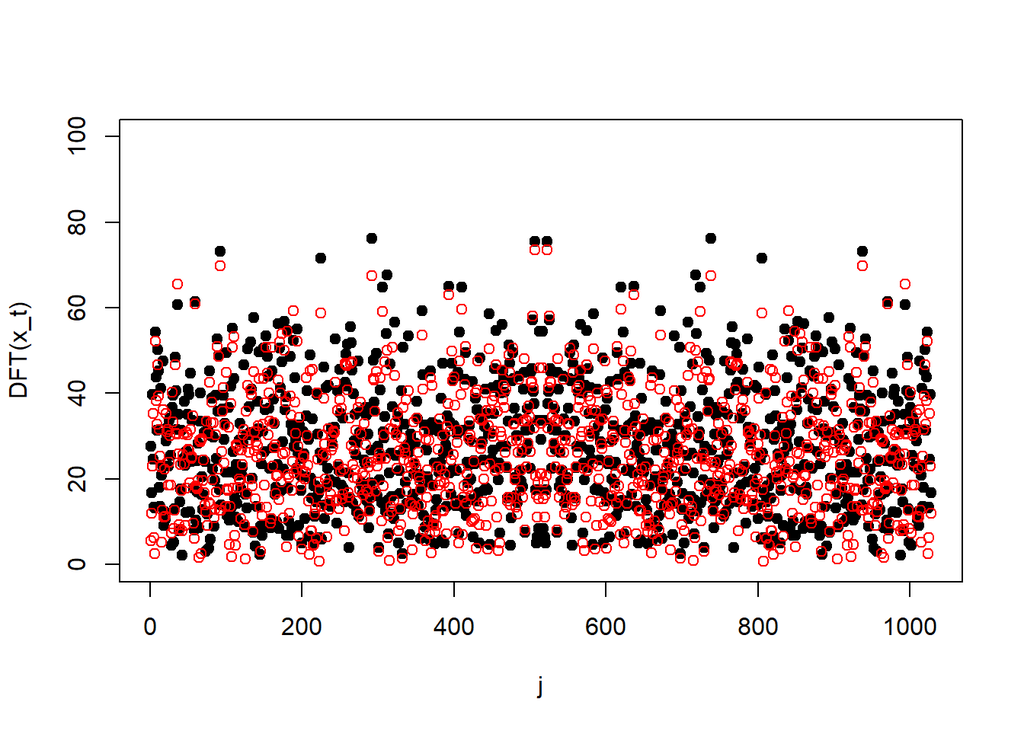

The magnitude of the points from the process with missing values are generally lower than those of the original full dataset.